# Start-to-end analysis with aRchiteutis

# 3. Composition

Three complementary views of *what is there*. `df2donut()` shows the mean composition across all samples, `df2composition()` stacks each sample, and `df2barplot()` shows the per-taxon distribution. All three already use viridis internally.

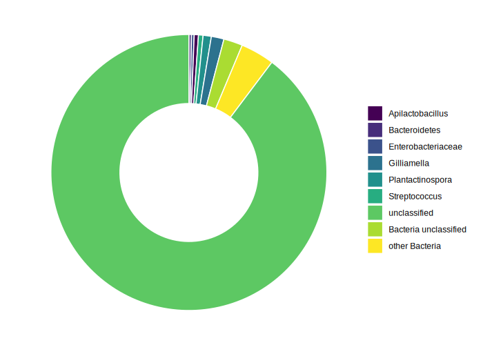

```r
df2donut(df_top)
```

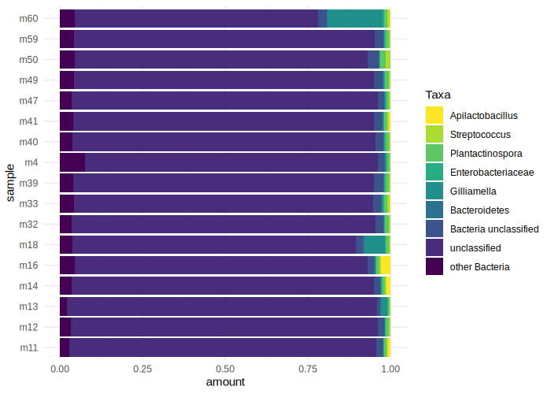

```r
df2composition(df_top)
```

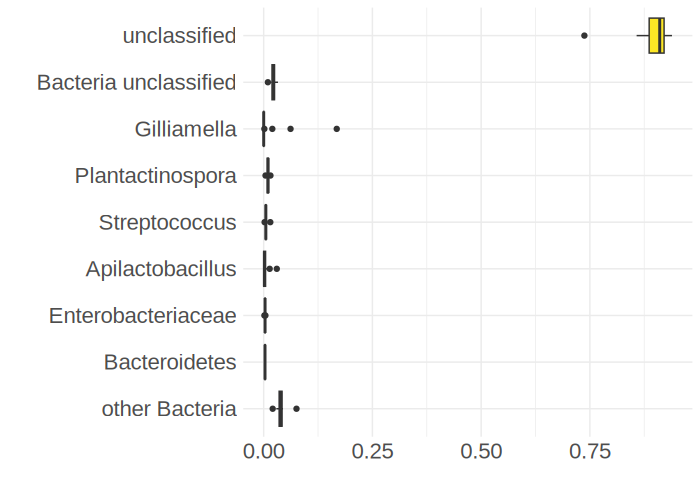

```r
df2barplot(df_top)
```

`df2barplot()` (and the alpha-diversity plots) can also draw a combined half-violin / half-boxplot via the optional [`ggviolinbox`](https://github.com/dsmutin/ggviolinbox) package. The chunk below only runs when that package is installed.

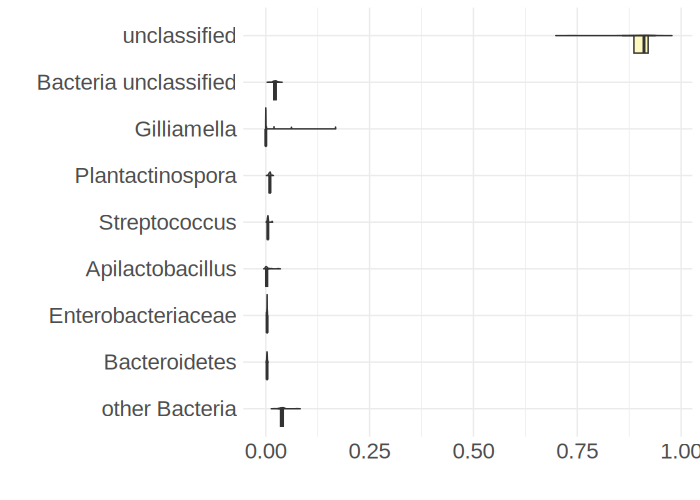

```r
df2barplot(df_top, violinbox = TRUE)
```

# 4. Alpha diversity

`df2alpha_summary()` computes a broad panel of alpha-diversity indices per sample and shows them split by a legend variable; `df2alpha()` does the same for a chosen shortlist. Here we split by `stage` (column 7) and colour by `hive` (column 8).

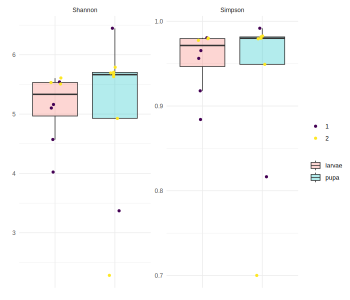

```r
df_sp <- df[df$clade == "S", ]
df2alpha(df_sp, split_by = 7, add_legend = 8)
```

## 4.1 Statistics: larvae vs pupa

To formally compare the two stages we compute the Shannon and Simpson indices per sample (with `abdiv`) and test the group difference with a Wilcoxon rank-sum test, annotated directly on the plot with `ggpubr::stat_compare_means()`. Fills use viridis and the theme is light.

```r
alpha_tab <- df_sp %>%
  dplyr::group_by(sample) %>%
  dplyr::summarise(
    Shannon = abdiv::shannon(N),
    Simpson = abdiv::simpson(N),
    .groups = "drop"
  )
alpha_tab <- dplyr::left_join(alpha_tab, meta, by = "sample")
alpha_long <- tidyr::pivot_longer(alpha_tab, c("Shannon", "Simpson"),
                                  names_to = "index", values_to = "value")
head(alpha_tab)
```

```
#> # A tibble: 6 × 5
#>   sample Shannon Simpson stage   hive
#>   <fct>    <dbl>   <dbl> <fct>  <int>
#> 1 m11       5.16   0.965 larvae     1
#> 2 m12       5.54   0.981 larvae     1
#> 3 m13       4.02   0.884 larvae     1
#> 4 m14       5.10   0.956 larvae     1
#> 5 m16       4.57   0.918 larvae     1
#> 6 m18       3.37   0.817 pupa       1
```

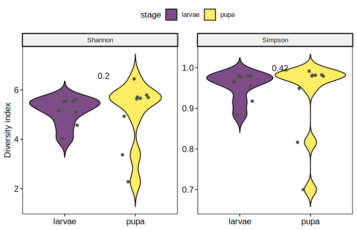

```r
ggpubr::ggviolin(
  alpha_long, x = "stage", y = "value", fill = "stage",
  palette = viridis::viridis(2), alpha = 0.7,
  add = "jitter", add.params = list(color = "grey30", size = 1.5),
  facet.by = "index", scales = "free_y"
) +
  ggpubr::stat_compare_means(
    ggplot2::aes(label = ggplot2::after_stat(p.format)),
    method = "wilcox.test", label.x.npc = "center"
  ) +
  labs(x = NULL, y = "Diversity index")
```

The p-value printed above each panel is the Wilcoxon test comparing larvae with pupa for that index.

# 5. Beta diversity

Beta diversity measures how different samples are from one another. `df2beta_pcoa()` builds a sample-by-sample distance matrix and ordinates it with PCoA. It supports three backends via `method`:

- `"bray"` — Bray-Curtis on proportions (the classic default);
- `"aitchison"` — compositional / log-ratio distance (`robCompositions::aDist()`, with zero replacement);
- `"adiv"` — Jaccard-family dissimilarity (`adiv::Jac()`).

We colour points by `stage` (column 7) and draw grouping ellipses.

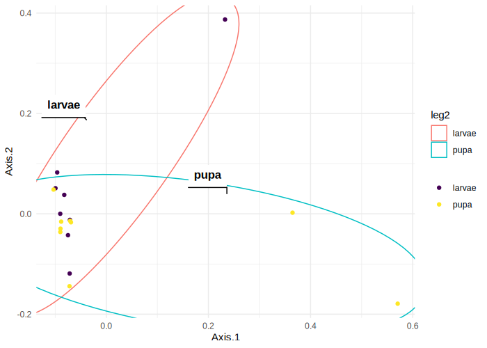

```r
df_g <- df[df$clade == "G", ]
df2beta_pcoa(df_g, method = "bray", add_legend = 7, add_ellipse = 7)
```

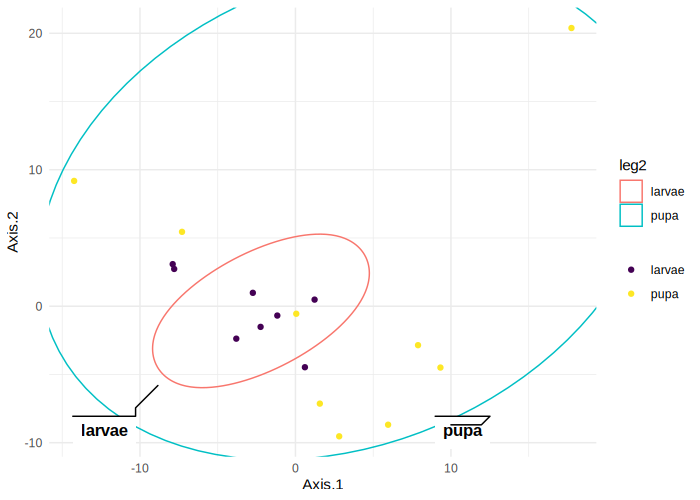

```r
df2beta_pcoa(df_g, method = "aitchison", add_legend = 7, add_ellipse = 7)
```

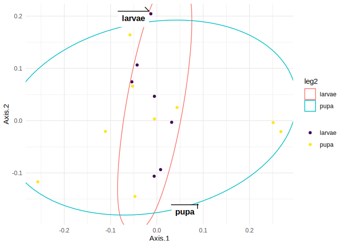

```r
df2beta_pcoa(df_g, method = "adiv", add_legend = 7, add_ellipse = 7)
```

## 5.1 Statistics: PERMANOVA

`df2beta(..., print_df = TRUE)` returns the raw distance matrix, which we can feed to `vegan::adonis2()` for a PERMANOVA test of whether stage explains a significant fraction of the between-sample variance.

```r
d_bray <- stats::as.dist(df2beta(df_g, method = "bray", print_df = TRUE))
grp <- meta$stage[match(labels(d_bray), meta$sample)]
```

```r
set.seed(1)
vegan::adonis2(d_bray ~ grp)
```

```
#> Permutation test for adonis under reduced model
#> Permutation: free
#> Number of permutations: 999
#>
#> vegan::adonis2(formula = d_bray ~ grp)
#>          Df SumOfSqs      R2      F Pr(>F)
#> Model     1  0.13816 0.08807 1.4486  0.221
#> Residual 15  1.43067 0.91193
#> Total    16  1.56884 1.00000
```

## 5.2 A polished PCoA scatter

For full control over styling we can ordinate the Bray-Curtis distance ourselves with `ape::pcoa()` and draw it with `ggpubr::ggscatter()`, adding confidence ellipses and group mean points in viridis.

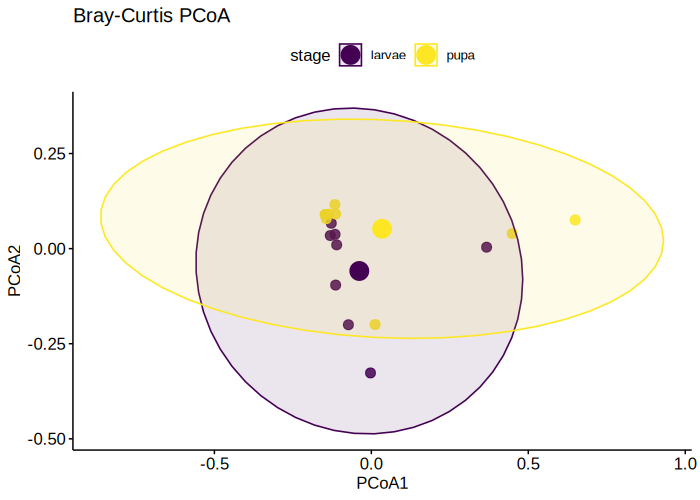

```r
pcoa <- ape::pcoa(as.matrix(df2beta(df_g, method = "bray", print_df = TRUE)))
scores <- as.data.frame(pcoa$vectors[, 1:2])
names(scores) <- c("PCoA1", "PCoA2")
scores$sample <- rownames(scores)
scores <- dplyr::left_join(scores, meta, by = "sample")

ggpubr::ggscatter(
  scores, x = "PCoA1", y = "PCoA2",
  color = "stage", palette = viridis::viridis(2),
  ellipse = TRUE, ellipse.type = "norm", mean.point = TRUE,
  size = 3, alpha = 0.85
) +
  labs(title = "Bray-Curtis PCoA")
```

# 6. Ordination, clustering and correlation

The matrix-oriented plots operate on a taxa-by-sample matrix such as `mat_g`.

`df2pca_sample()` runs a PCA of the samples. Encoding the legend into the column names lets us colour the individuals by stage.

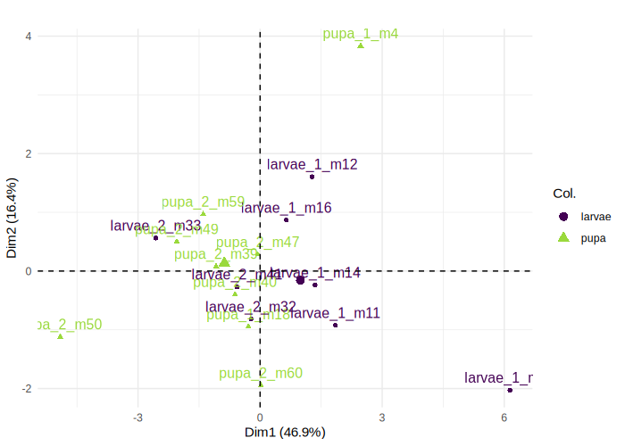

```r
mat_g_enc <- df_untidy(df, clade = "G", top = 12, keep_sample_name = FALSE)
df2pca_sample(mat_g_enc, detect = "pupa", detect2 = "larvae") +
  scale_color_viridis_d(end = 0.85)
```

`df2heatmap()` draws a base-graphics heatmap (viridis colour scale)…

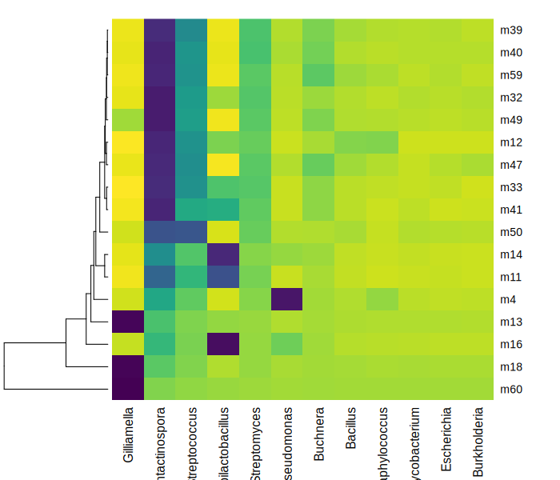

```r
df2heatmap(mat_g, scale = "row", Colv = NA)
```

…and `df2corrplot()` a clustered taxa-by-taxa correlation plot.

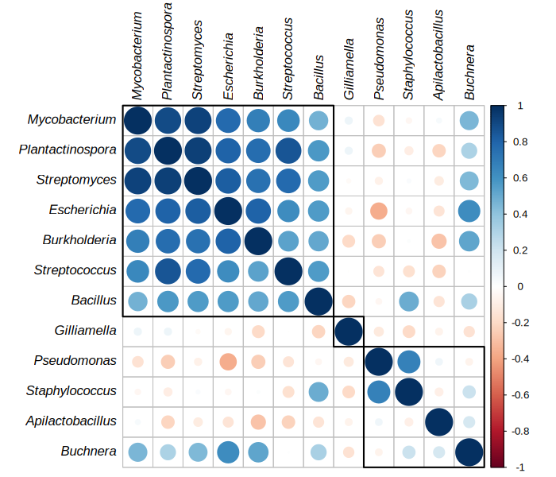

```r
df2corrplot(mat_g, k_means = 3)
```

t-SNE (`df2tsne()`) is available for larger taxa sets. It is iterative and can be slow, so we show the call but leave it un-evaluated in this quick build.

```r
mat_tsne <- df_untidy(df, clade = "G", top = 40, scale = "scale")
set.seed(1)
df2tsne(mat_tsne, k_means = 4, text_top = 5, perplexity = 5, max_iter = 300)
```

# 7. Differential abundance

`df2volcano()` runs a per-taxon *t*-test between two sample groups and plots the log abundance change against the p-value. Here we contrast pupa with larvae at the genus level.

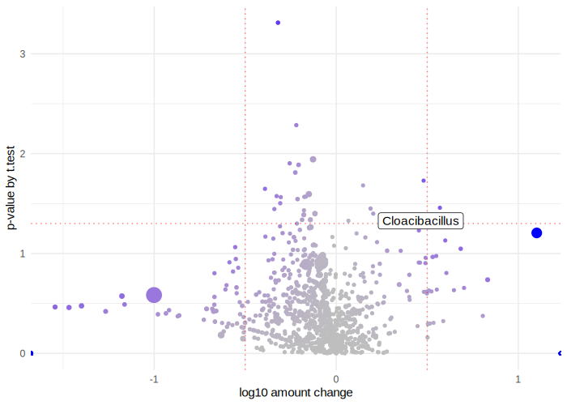

```r
df2volcano(df_g, legend_detect = c("pupa", "larvae"))
```

# 8. Co-occurrence networks

`df2graph()` turns a taxa-by-sample matrix into an annotated `tidygraph::tbl_graph` (node centralities + community membership, signed correlation edges) and `df2ggraph()` draws it with `ggraph` — communities in viridis, edges coloured by the sign of the correlation.

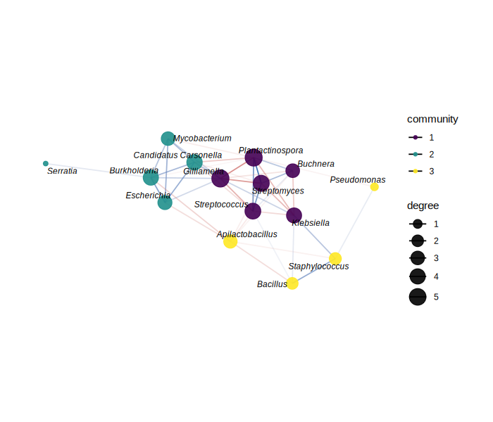

```r
mat_net <- df_untidy(df, clade = "G", top = 15, scale = "scale")
set.seed(1)
df2ggraph(mat_net, threshold = 0.3)
```

## 8.1 NetCoMi networks (optional)

For association networks with dedicated microbiome methods (SparCC, SPIEC-EASI, SPRING, …), `df2netcomi()` wraps [`NetCoMi`](https://github.com/stefpeschel/NetCoMi), and `df2netcomi_graph()` bridges the result into the *same* `df2ggraph()` engine for a consistent look. `NetCoMi` is a heavy optional dependency, so the chunk below is shown for reference but not evaluated; install `NetCoMi` and set `eval = TRUE` to run it.

```r
res <- df2netcomi(mat_net, measure = "pearson", thresh = 0.3)
res$props                                 # network summary statistics
df2netcomi_graph(res, plot = TRUE)        # drawn with df2ggraph()
```